# Project: exclusionPower

Thore, Elias and Magnus

Created: Jul 31, 2019

## Missing Grandchild Example

Below is an example based on the Argentina paper, see Figure 6, Kling et al (2017), https://github.com/thoree/exclusion/blob/master/F21/Kling-missing-PIIS1872497317301758.pdf. The pedigrees are larger than usual, parents of PO typically not available, and mutations happen. Files are in in https://github.com/thoree/exclusion/tree/master/F21. The data has been exported from Windows Familias and converted using `forrel::Familias2ped`. Then it was saved using the R function `save`. Below it’s loaded (I unsuccesfuly tried several ways of direct load from github) and some examples are shown based on the 5 markers published

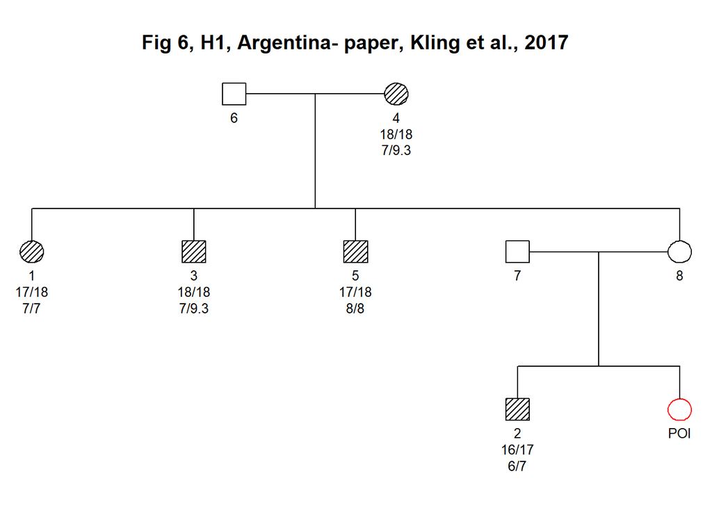

```r
load("exampleA3.RData")
x = exampleA3
library(forrel, quietly = TRUE)
claim = x[[1]][[1]] # remove singleton, just for first plot
knitr::opts_chunk$set(fig.width=12, fig.height=8)
plot(claim, marker = 1:2, cex = 0.8,  skip.empty.genotypes = TRUE,
     shaded = 1:5, col = list(red = "POI"),
     title = "Fig 6, H1, Argentina- paper, Kling et al., 2017")
```

Exclusion probability for first marker:

```r
claim = x[[1]]
true = x[[2]]
(PE1 = exclusionPower(claim, true, ids = "POI", markerindex = 1,
               verbose = FALSE))
```

```
## [1] 0.5213632
```

Let’s check the answer with some acrobatics, since `oneMarkerDistribution`does not accept lists:

```r
library(pedprobr)
H2 = x[[2]][[1]]
H2 = addChildren(H2, father = 2, mother = "POI", id = "NN",
                 verbose = FALSE)
ptrue = oneMarkerDistribution(H2,ids = "POI", partialmarker = 1,
                              verbose = F)

H1 = x[[1]][[1]]
pclaim = oneMarkerDistribution(H1,ids = "POI", partialmarker = 1,
                              verbose = F)
I1 = (pclaim == 0)
PE.check = sum(I1*ptrue)
c("PE1 = ", PE1, "PE.check =", PE.check)
```

```
## [1] "PE1 = "            "0.521363167706383" "PE.check ="
## [4] "0.521363167706383"
```

A closer look at the second marker: We see that there must be a mutation in `5` and mutations are modelled only for this marker. In this case, `the`proportional` model with mutation rate 0.005, was specified in Windows Familias. In the ped-suite, we can look at the mutation model (output omitted)

```r
library(pedmut)
m = claim[[1]]$markerdata[[2]]
mutmod(m)
```

Exclusion probability for second marker (problem with `markerindex` see https://github.com/magnusdv/forrel/issues/23; skip the rest for now)

```r
exclusionPower(claim, true, ids = "POI", markerindex = 2,
               verbose = FALSE)
```

```
## [1] 0
```

Exclusion probability for markers 1,2,3,4,5

```r
nMarkers = 5
PE = rep(NA, nMarkers)
for (i in 1:5)
  PE[i] = exclusionPower(claim, true, ids = "POI", markerindex = i, plot = FALSE,
                         verbose = FALSE)
PE.all = 1 - prod(1-PE)
c("PE = " = PE.all)
```

```
##     PE =
## 0.7920915
```

## epGUI testing

We start with some simplified test cases for the `epGUI`. Assume only 7 and POI will be genotyped and that no others are genotyped.

```r
x = exampleA3
for (i in 1:5){
 genotype(x[[1]][[1]], "D3S1358", i) = NA
 genotype(x[[1]][[1]], "TH01", i) = NA
}
claim = x[[1]]
true = x[[2]]
PE1 = exclusionPower(claim, true, ids = c("7", "POI"), markerindex = 1,
               verbose = FALSE,plot = F)
mutmod(claim[[1]], marker = 2) = "trivial" #removes mutation
PE2 = exclusionPower(claim, true, ids = c("7", "POI"), markerindex = 2,
               verbose = FALSE, plot = F)
c("D3S1358" = PE1, "TH01" = PE2)
```

```
##   D3S1358      TH01
## 0.3534646 0.3720169
```

These numbers confirm epGUI output based on claim2.ped, true.ped and database.csv in https://github.com/thoree/exclusion/tree/master/F21/ep

Assume next 7 is genotyped

```r
genotype(x[[1]][[1]], "D3S1358", 7) = c(16, 16)
genotype(x[[1]][[1]], "TH01", 7) = c(6, 6)
claim = x[[1]]
mutmod(claim[[1]], marker = 2) = "trivial" #removes mutation
true = x[[2]]
PE1 = exclusionPower(claim, true, ids = c("7", "POI"), markerindex = 1,
               verbose = FALSE,plot = F)
PE2 = exclusionPower(claim, true, ids = c("7", "POI"), markerindex = 2,
               verbose = FALSE, plot = F)
c("D3S1358" = PE1, "TH01" = PE2)
```

```
##   D3S1358      TH01
## 0.5187540 0.4961653
```